# DATA 605 Week 1 Homework

Ilya Kats

September 2, 2017

## Problem Set 1

My approach for problem set 1 was to do all computations manually, but then I have double-checked them with R code. *Side note:* It took me embarrassingly long time to realize that I need to make sure that the aspect ratios of x axis and y axis in the plot should match if I want to double-check the angle visually.

### Part (1)

If

$u=[0.5, 0.5]$

$v=[3, -4]$

Then dot product is

$$\begin{split}
u \cdot v &= [0.5, 0.5] \cdot [3, -4] \\
&= 0.5 * 3 + 0.5 * (-4) \\
&= 1.5 - 2 \\
&= -0.5
\end{split}$$

Check with R…

```r
u <- c(0.5, 0.5)
v <- c(3, -4)
dot_uv <- drop(u %*% v)
dot_uv
```

```
## [1] -0.5
```

### Part (2)

Length of vector $u$

$$\begin{split}
\left\| u \right\| &= \sqrt{0.5^2 + 0.5^2} \\
&= \sqrt{0.25 + 0.25} \\
&= \sqrt{0.5} \approx{0.7071}
\end{split}$$

Length of vector $v$

$$\begin{split}
\left\| v \right\| &= \sqrt{3^2 + {(-4)}^2} \\
&= \sqrt{9 + 16} \\
&= \sqrt{25} \\
&= 5
\end{split}$$

Check with R…

```r
len_u <- sqrt(u[1]^2 + u[2]^2)
len_v <- sqrt(v[1]^2 + v[2]^2)
len_u
```

```
## [1] 0.7071068
```

```r
len_v
```

```
## [1] 5
```

### Part (3)

$$\begin{split}
3u - 2v &= 3 [0.5, 0.5] - 2 [3, -4] \\
&= [3*0.5, 3*0.5] - [2*3, 2*(-4)] \\
&= [1.5, 1.5] - [6, -8] \\
&= [1.5 - 6, 1.5 - (-8)] \\
&= [-4.5, 9.5]
\end{split}$$

Check with R…

```r
3*u - 2*v
```

```
## [1] -4.5  9.5
```

### Part (4)

Let $\theta$ be an angle between vectors $u$ and $v$, then

$$\begin{split}
\cos(\theta) &= \frac{u \cdot v}{\left\| u \right\|\left\| v \right\|}\\
&= \frac{-0.5}{0.7071 * 5} \approx -0.1414
\end{split}$$

```r
cos_theta <- dot_uv / (len_u * len_v)
cos_theta
```

```
## [1] -0.1414214
```

```r
theta <- acos(cos_theta) * 180/pi
theta
```

```
## [1] 98.1301
```

Based on R code above the angle is $\theta = cos^{-1}(-0.1414) \approx 98.13^{\circ}$.

Confirm results by plotting two vectors…

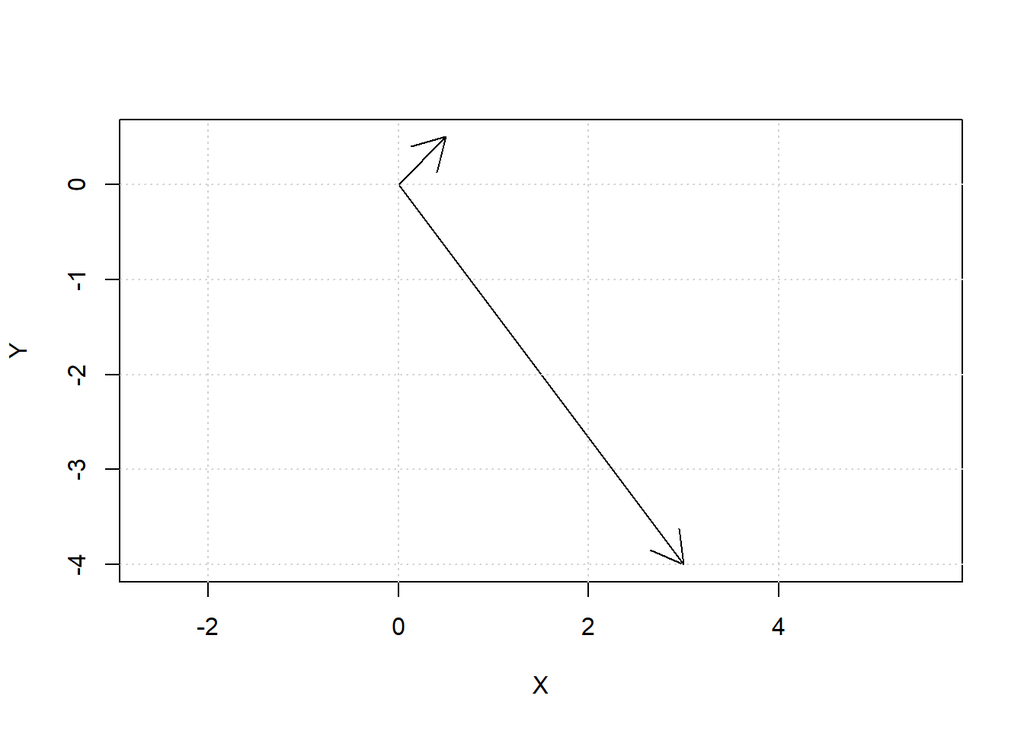

```r
plot(NA, xlim=c(0,3), ylim=c(-4,0.5), xlab="X", ylab="Y", asp=1)
arrows(0,0,0.5,0.5)
arrows(0,0,3,-4)
grid()
```

## Problem Set 2

### Generate Row-Equivalent Matrix in Echelon Form

The following code is based on the **Gauss-Jordan elimination** algorithm presented in Subsection RREF of the *A First Course in Linear Algebra* book by Robert A. Beezer. The `echelon` function works on any size coefficient matrix.

```r
# Generate row-equivalent matrix in echelon form
# A is a coefficient matrix
# b is vector of constants
echelon <- function(A, b) {
  A1 <- cbind(A,matrix(b))

  m <- dim(A)[1]
  n <- dim(A)[2]

  r <- 0
  for(j in 1:n) {
    i <- r+1
    if(i <= m) {
      A1ij <- A1[i,j]
    }
    while (i <= m & A1ij==0) {
      i <- i+1
      if(i <= m) {
        A1ij <- A1[i,j]
      }
    }
    if(i < m+1) {
      r <- r+1

      # Swapping rows i and r (row operation 1)
      temprow <- A1[i, ]
      A1[i, ] <- A1[r, ]
      A1[r, ] <- temprow

      # Scale A[r,j] to 1 (row operation 2)
      multiplier <- A1[r,j]
      for(t in 1:(n+1)) {
        A1[r,t] <- A1[r,t] / multiplier
      }

      # Zero out all other values in the column (row operation 3)
      for(k in 1:m) {
        if(k!=r) {
          multiplier <- A1[k,j]
          for(t in 1:(n+1)) {
            A1[k,t] <- A1[k,t] - A1[r,t] * multiplier
          }
        }
      }
    }
  }
  return(A1)
}
```

### Examples

Even though the code above works on any size system of equations, examples and code below only test systems of 3 variables and 3 constraints. The code in all examples is the same. To test other examples, only adjustments to `A` and `b` are needed.

#### EXAMPLE 1

```r
# Coefficient matrix
A <- matrix(c(1,2,-1,1,-1,-2,3,5,4), nrow = 3)
A
```

```
##      [,1] [,2] [,3]
## [1,]    1    1    3
## [2,]    2   -1    5
## [3,]   -1   -2    4
```

```r
# Vector of constants
b <- c(1,2,6)
b
```

```
## [1] 1 2 6
```

```r
# Row-equivalent matrix in echelon form
Ae <- echelon(A, b)
Ae
```

```
##      [,1] [,2] [,3]       [,4]
## [1,]    1    0    0 -1.5454545
## [2,]    0    1    0 -0.3181818
## [3,]    0    0    1  0.9545455
```

```r
# Find and output solution(s)
onesolution <- TRUE
for(i in 1:dim(A)[1]) {
  if (all(Ae[i, 1:dim(A)[2]]==0)) {
    if (Ae[i,dim(Ae)[2]]==0) {
      msg <- "There are infinitely many solutions."
    } else {
      msg <- "There are no solutions."
    }
    onesolution <- FALSE
  }
}
```

**SOLUTION:**

```r
if (onesolution) {
  msg <- "There is only one solution."
  Ae[,dim(Ae)[2]]
}
```

```
## [1] -1.5454545 -0.3181818  0.9545455
```

```r
print(msg)
```

```
## [1] "There is only one solution."
```

Because of rounding when converting the systen to echelon form, the solution does not match exactly the solution specified in the problem ([-1.55, -0.32, 0.95]).

#### EXAMPLE 2

```r
# Coefficient matrix
A <- matrix(c(3,5,2,4,-2,-2,-1,1,1), nrow = 3)
A
```

```
##      [,1] [,2] [,3]
## [1,]    3    4   -1
## [2,]    5   -2    1
## [3,]    2   -2    1
```

```r
# Vector of constants
b <- c(8,4,1)
b
```

```
## [1] 8 4 1
```

```r
# Row-equivalent matrix in echelon form
Ae <- echelon(A, b)
Ae
```

```
##      [,1] [,2] [,3] [,4]
## [1,]    1    0    0    1
## [2,]    0    1    0    2
## [3,]    0    0    1    3
```

```r
# Find and output solution(s)
onesolution <- TRUE
for(i in 1:dim(A)[1]) {
  if (all(Ae[i, 1:dim(A)[2]]==0)) {
    if (Ae[i,dim(Ae)[2]]==0) {
      msg <- "There are infinitely many solutions."
    } else {
      msg <- "There are no solutions."
    }
    onesolution <- FALSE
  }
}
```

**SOLUTION:**

```r
if (onesolution) {
  msg <- "There is only one solution."
  Ae[,dim(Ae)[2]]
}
```

```
## [1] 1 2 3
```

```r
print(msg)
```

```
## [1] "There is only one solution."
```

#### EXAMPLE 3

```r
# Coefficient matrix
A <- matrix(c(5,4,-1,-2,-4,1,1,-8,2), nrow = 3)
A
```

```
##      [,1] [,2] [,3]
## [1,]    5   -2    1
## [2,]    4   -4   -8
## [3,]   -1    1    2
```

```r
# Vector of constants
b <- c(3,2,-3)
b
```

```
## [1]  3  2 -3
```

```r
# Row-equivalent matrix in echelon form
Ae <- echelon(A, b)
Ae
```

```
##      [,1] [,2]     [,3]       [,4]
## [1,]    1    0 1.666667  0.6666667
## [2,]    0    1 3.666667  0.1666667
## [3,]    0    0 0.000000 -2.5000000
```

```r
# Find and output solution(s)
onesolution <- TRUE
for(i in 1:dim(A)[1]) {
  if (all(Ae[i, 1:dim(A)[2]]==0)) {
    if (Ae[i,dim(Ae)[2]]==0) {
      msg <- "There are infinitely many solutions."
    } else {
      msg <- "There are no solutions."
    }
    onesolution <- FALSE
  }
}
```

**SOLUTION:**

```r
if (onesolution) {
  msg <- "There is only one solution."
  Ae[,dim(Ae)[2]]
}

print(msg)
```

```
## [1] "There are no solutions."
```

#### EXAMPLE 4

```r
# Coefficient matrix
A <- matrix(c(1,-3,4,-2,6,-8,1,-3,4), nrow = 3)
A
```

```
##      [,1] [,2] [,3]
## [1,]    1   -2    1
## [2,]   -3    6   -3
## [3,]    4   -8    4
```

```r
# Vector of constants
b <- c(3,-9,12)
b
```

```
## [1]  3 -9 12
```

```r
# Row-equivalent matrix in echelon form
Ae <- echelon(A, b)
Ae
```

```
##      [,1] [,2] [,3] [,4]
## [1,]    1   -2    1    3
## [2,]    0    0    0    0
## [3,]    0    0    0    0
```

```r
# Find and output solution(s)
onesolution <- TRUE
for(i in 1:dim(A)[1]) {
  if (all(Ae[i, 1:dim(A)[2]]==0)) {
    if (Ae[i,dim(Ae)[2]]==0) {
      msg <- "There are infinitely many solutions."
    } else {
      msg <- "There are no solutions."
    }
    onesolution <- FALSE
  }
}
```

**SOLUTION:**

```r
if (onesolution) {
  msg <- "There is only one solution."
  Ae[,dim(Ae)[2]]
}

print(msg)
```

```
## [1] "There are infinitely many solutions."
```